# Logistic Regression to Predict Insurance Claims

Cody Clayton

Date: September 17, 2017

# Objective

The objective of this project is to identify auto insurance buyers who have a higher risk of submitting a claim within a policy’s first year based on the information available at the time of purchase. This information can then be used as a tool when determining the appropriate premium to charge the buyer in order to lower the company’s expenses.

# Data Exploration and Insights

To create an effective model, we must first ensure that the policy characteristics being used are accurate, available at the time of purchase and predictive of a claim submission. To ensure this:

1. Only the data available before the policy is taken out can be used. Therefore, the information regarding the **number of claims submitted** and the **amount of the claims** will not be considered.
2. Data that has no predictive power can be removed. Since the **X_OBSTAT_** feature has the same value for all policies, it can be ignored.
3. Data that is inaccurate should be transformed or removed. 53 policies have a **vehicle value** of $0.00 which is incorrect. Furthermore, the exposure value for these 53 policies also appears to be inflated as 43.40% have an **exposure** above 0.99. In comparison to the population, only 2.44% have an **exposure** above 0.99. For these reasons and because this only represents a very small portion of the population, they will be removed.

It is also important to examine the features to determine if there are any obvious correlations to a claim submission. If we break down the proportion of policies that sumbit a claim based on the claim characteristics, we are able to see a few obvious patterns.

1. There is a clear relationship between the driver’s **age** and the submission of a claim. As driver age increases, the percentage of vehicles that submit a claim decreases.

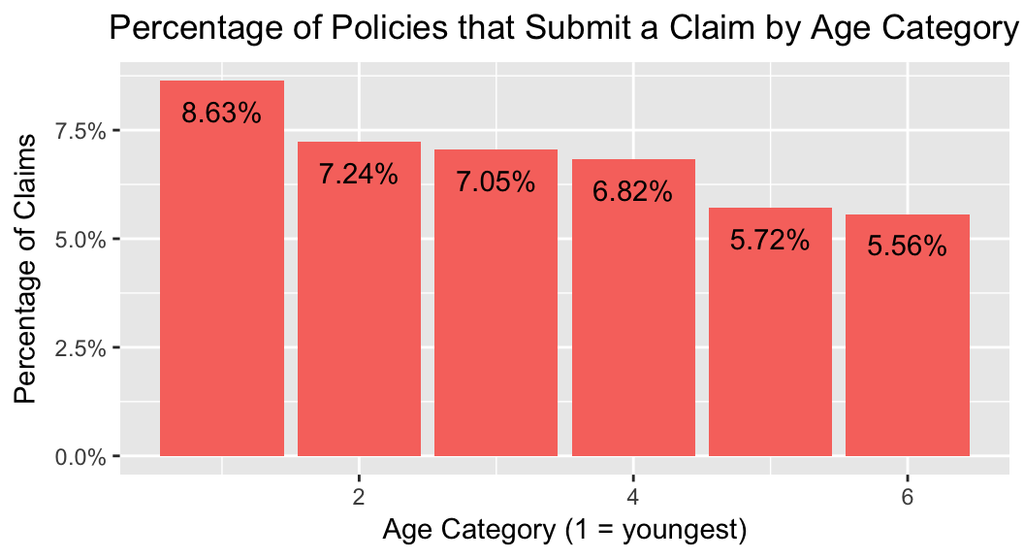

2. Higher **exposure** could also be a good predictor, as policies with high exposure appear to be more likely to submit a claim.

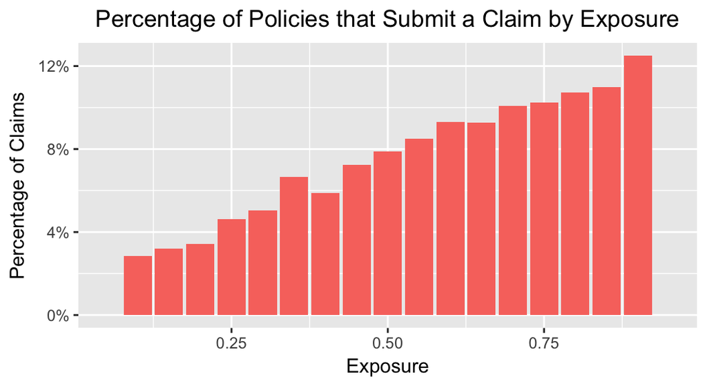

3. There could also be a relationship between some **vehicle body types** and the submission of a claim.

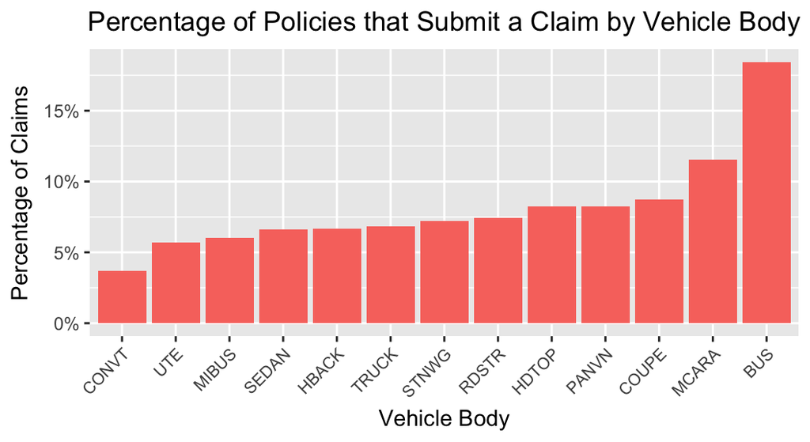

4. The **vehicle values** cover a large range, from $1,800 to $345,600, and have a very skewed distribution. As a result, a log transformation will be considered on this data when building the model. This will result in a more $normal$ distribution and may improve the model’s quality if differences in magnitude are more informative than differences in the value itself.

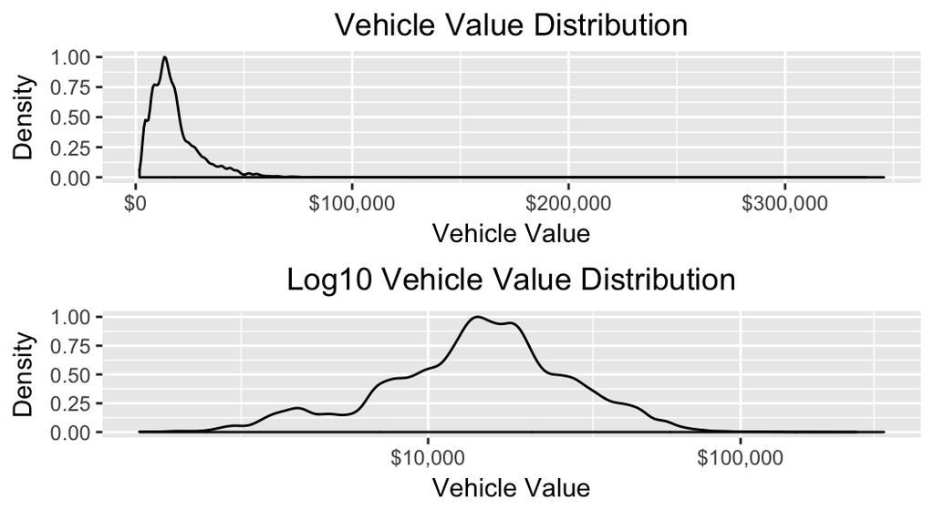

5. There is no clear relationship between **area**, **vehicle value**, **vehicle age** or **gender** and the liklihood of submitting a claim. However, these features will still be considered for the model.

# Model Selection & Description

Logistic regression was selected for this project because it is the most widely used and approved method for predicting probabilities or rates.

Logistic regression can predict the probability that an instance belongs to a specific category (in this case, the probability that a vehicle will submit an insurance claim in the first year) based on the input features provided (**age**, **gender**, **exposure**, etc.).

The coefficients of a logistic regression model can also be treated as advice when selecting which features to include in the model and also in determining which features have the largest impact on the output.

## Predicting Insurance Claims with Logistic Regression

The best performing and most accurate model is a logistic regression model which predicts the probability of a first year claim based on the **exposure**, **age**, **vehicle body**, and the log transformed **vehicle value** characteristics . Although including the **area**, **vehicle age** and **gender** did increase the model’s pseudo r-squared slightly, the model’s AIC (Akaike information criterion) also increased indicating a poorer fit.

## Threshold Selection and Performance

The model was trained using 80% of the available data. The remaining 20% was used to assess the model’s accuracy. To evaluate the overall quality of the model, 100 iterations of this split were performed.

In order to use the model as a classifier, we must first select a probability threshold based on the model’s predictions for the test data. The goal is to balance the precision of the classifier (what percentage of the predicted positives actually submit a claim) and its recall (what percentage of policies that actually submit a claim did the model identify). Since we are predicting a rare event (only 6.81% of policies submit a claim), the two distributions aren’t well separated.

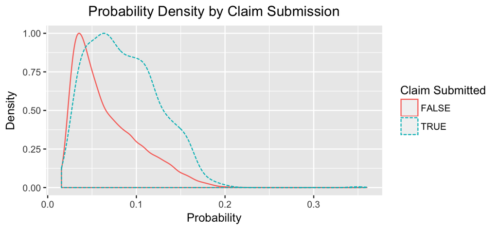

This indicates that we are unable to select a threshold that achieves both high recall and good precision simultaneously. However, we can build a classifier that identifies policies with a higher-than-average rate of claims compared to the population. The ratio of the classifier’s precision to the average rate of positives in the population is called the enrichment rate.

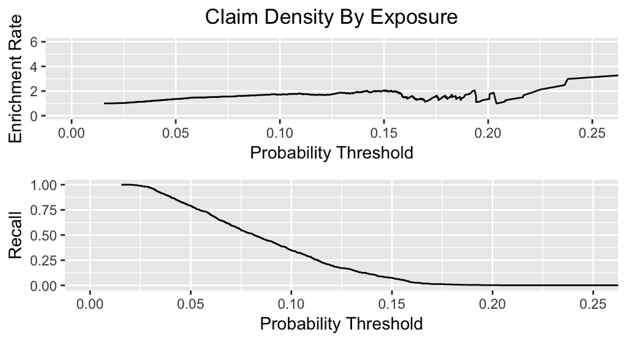

Selecting a threshold of 0.15 results in a precision of 13.83% which is more than double the rate of positives in the population. This results in an enrichment rate of 2.06. However the recall at this threshold is only 7.47%. We are only able to identify a small portion of the policies that actually submit a claim.

If instead we select a threshold of 0.10, this results in a precision of 11.51% and a 1.72 enrichment rate. The recall is 34.85%. We are able to identify a much larger portion of the policies which will submit a claim for a small decrease in the model’s precison.

## Model Validation and Selection of Inputs

The policy characteristics were selected based on the model’s coefficent values and their significance. The significance was evaluated using the chi-squared test on the deviance between the logistic regression model and the NULL model. The goodness of fit was validated via the pseudo r-squared. The **age**, **vehicle value**, **vehicle body** and **exposure** all improved on the model’s quality.

The 80/20 train and test split was performed 100 times to calculate the p-value from the chi-squared test, the pseudo r-squared and the AIC.

### Chi-squared Test On The Deviance

The chi-squared test informs us if the reduction in the deviance from the model is statistically significant or if it could have been observed by chance. The average p-value for the 100 models is 3.2606e-206. Since this value is very small, it indicates the reduction in the deviance was not observed by chance and we therefore have a valid model.

### Pseudo R-squared & Akaike Informaion Criterion

The average pseudo r-squared over the 100 iterations was 3.87% implying the model can only explain about 3-4.5% of the deviance. This indicates that although it is a legitimate model, we may not have access to all the information required to accurately predict the probability of an insurance policy holder submitting a claim. The average AIC for the 100 models is 25935.

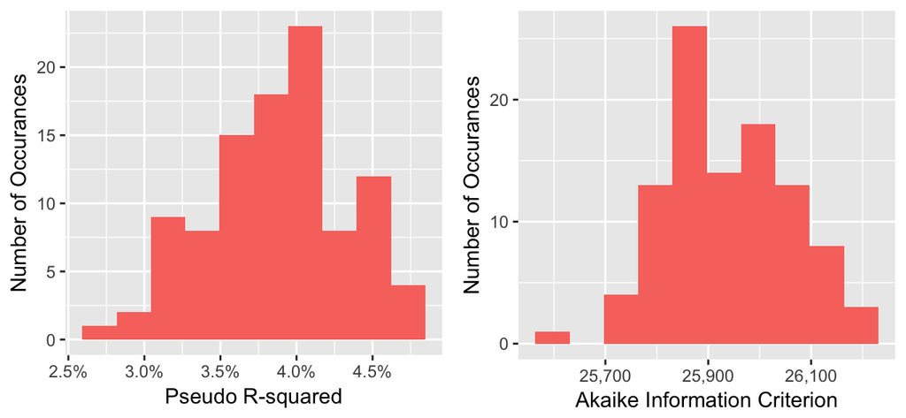

### Model Summary & Coefficients

As mentioned previously, the AIC, the coefficients and the pseudo r-squared were used to decide which features to include in the model. Including the **gender**, **area** and **vehicle age** only increased the pseudo r-squared slightly but also increased the AIC. Since all the possible models were trained with the same training set, the model with the lowest AIC is considered the best fit. The summary of the different model results can be seen below.

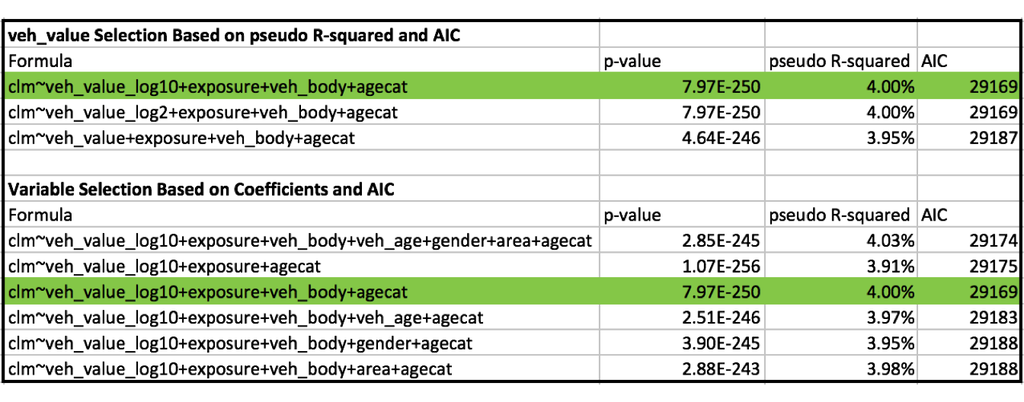

# Assumptions required for results to be predictive in 2006

1. The **exposure** must be available before the insurance policy is taken out. It can therefore be used as a predictor at the time of purchase.
2. The dataCar dataset must only indicate a vehicle has submitted a claim if the claim occurs in the first year. The dataset includes data from 2004 and 2005. If a policy was taken out in 2004 and was renewed in 2005, the 2005 renewal and any claim that happened after the renewal date should not be included.